# MetaP2

Jake VanCampen

2018-03-08

Repeat nMDS using randomly selected genes from stickleback.csv

```r
## Read in TMM-normalized values for complement and coagulation genes
stickle <- read.delim("data/stickleback_CPM.tsv", sep = "\t",
                      row.names = 1, header = T)
dim(stickle)
```

```
## [1] 15847    86
```

```r
## Read in the metadata
stickle_meta <- read.delim("data/stickleback_metadata.tsv", sep = "\t", header = T)
head(stickle_meta)
```

```
##   ID    SEX
## 1 M1   male
## 2 F2 female
## 3 F3 female
## 4 M4   male
## 5 F5 female
## 6 M6   male
```

We can look at both a random sample, and a sample of sex_specific genes

## Sex specific

```r
## Get only those genes from the region of chromosome 19 that is sex-specific
subsample1 <- stickle[stickle$Genome_Loc=="groupXIX" &
                        stickle$Gene_Start_Pos>=6000000 &
                        stickle$Gene_Start_Pos<=12000000, ]

dim(subsample1)
```

```
## [1] 314  86
```

## Random Subsample

```r
# sample 314 randomly selected genes
stickle_rand <-  stickle %>% sample_n(314)

# 314 genes, 86 individauls
dim(stickle_rand)
```

```
## [1] 314  86
```

## Sex Specific

```r
#### Let's start by using nMDS to see whether male-female expression differences exist

## A bit of reformatting
nmds_expr <- subsample1[,3:86]
nmds_expr_t <- t(nmds_expr)

## Generate dissimilarity matrix
vare.dis <- vegdist(nmds_expr_t)

## Generate nmds "latent variables" and evaluate fit
vare.mds0 <- isoMDS(vare.dis, k=2)
```

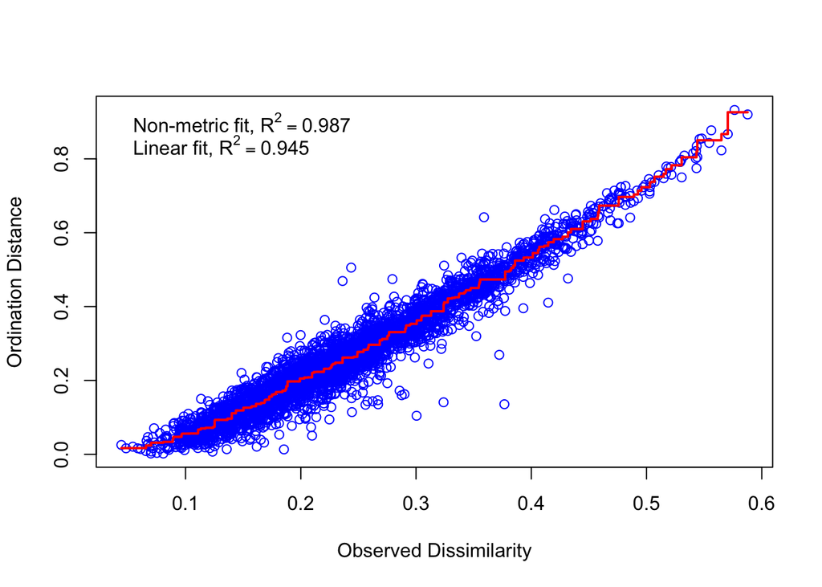

```r
stressplot(vare.mds0, vare.dis)
```

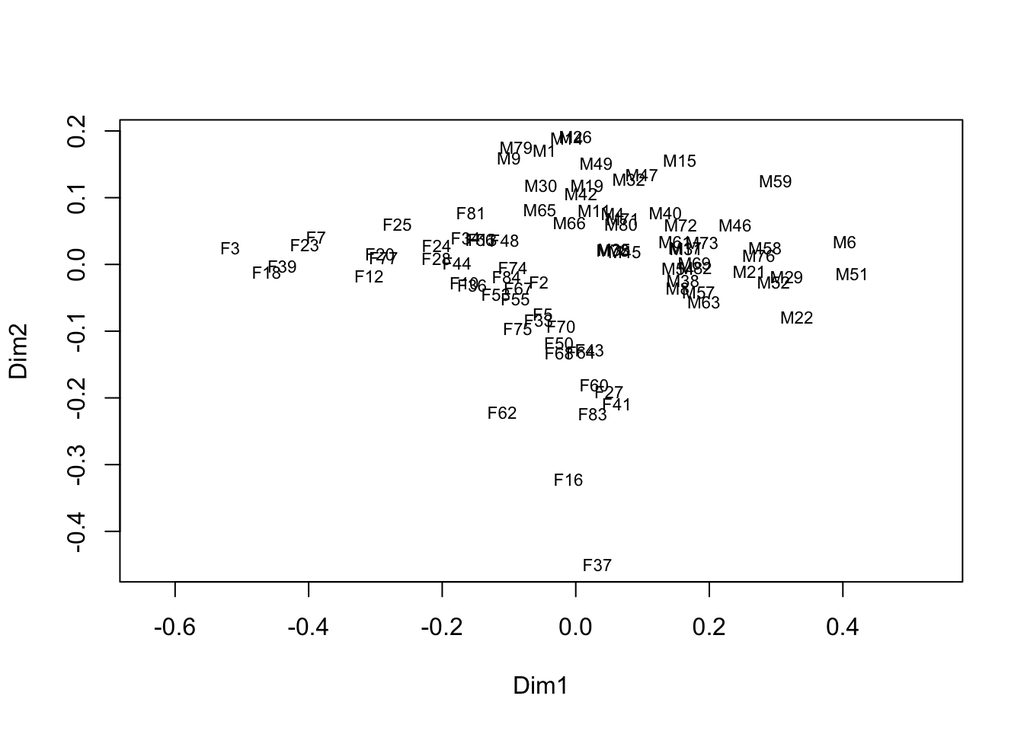

```r
## plot nmds 2 vs nmds 1
ordiplot(vare.mds0, type = "t")
```

## Random Subsample

```r
#### Let's start by using nMDS to see whether male-female expression differences exist

## A bit of reformatting
nmds_expr <- stickle_rand[,3:86]
nmds_expr_t <- t(nmds_expr)

## Generate dissimilarity matrix
vare.dis <- vegdist(nmds_expr_t)

## Generate nmds "latent variables" and evaluate fit
vare.mds0 <- isoMDS(vare.dis, k=2)
```

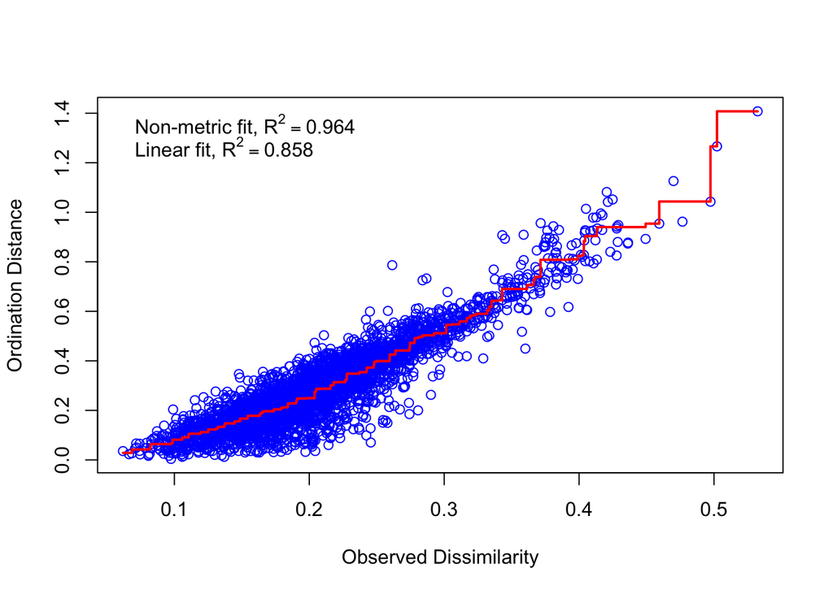

```r
stressplot(vare.mds0, vare.dis)
```

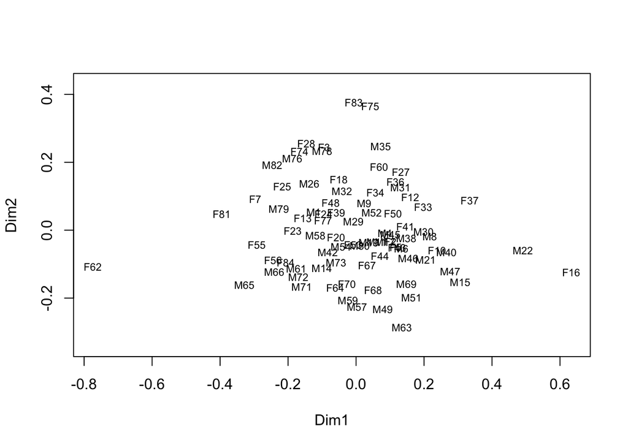

```r
## plot nmds 2 vs nmds 1
ordiplot(vare.mds0, type = "t")
```

The stressplots show that the sex-specific subsample does better than the random selected sub_sample, and the ordination plot using random sampled genes does not show clear separation between male and female.

## Random Forrest - Sex Specific

Now, let’s run random forest using all 84 samples and all 314 genes But first, some more reformatting

```r
#### Now, let's run random forest using all 84 samples and all 314 genes
## But first, some more reformatting

## subset only the data columns and log-transform
RF_expr <- log2(subsample1[,3:86]+.01)

# Mean-center and range data (mean 0, sd 1). Must transpose for row wise scaling
RF_expr.n <- data.frame(scale(t(RF_expr)))

## add the classifier variable (sex, in this case)
RF_expr.n$sex <- stickle_meta[,2]
#head(RF_expr.n)

## Run RF to classify males and females
## ntree = number of dec. trees (501 is pretty low, but will be fast)
## mtry = number of variables randomly sampled at each tree node. Default sqrt(num predictors)

RF_sex_classify <- randomForest(x=RF_expr.n[,1:314],
                                y=RF_expr.n[,315],
                                ntree=501, importance=TRUE,
                                proximities=TRUE)

RF_sex_classify
```

```
##
## Call:
##  randomForest(x = RF_expr.n[, 1:314], y = RF_expr.n[, 315], ntree = 501,      importance = TRUE, proximities = TRUE)
##                Type of random forest: classification
##                      Number of trees: 501
## No. of variables tried at each split: 17
##
##         OOB estimate of  error rate: 0%
## Confusion matrix:
##        female male class.error
## female     40    0           0
## male        0   44           0
```

```r
## Fit implies perfect classification, but can also evaluate with a permutation test
## This will take several minutes, so I won't re-run during class.

  #RF_sex_classify_sig <- rf.significance(x=RF_sex_classify,  xdata=RF_expr.n[,1:314],
  #                                       nperm=1000, ntree=501 )
  #
  #saveRDS(RF_sex_classify_sig, 'RF_sex.rds')
## Model also classifies significantly better than expected by chance.

RF_sex_classify_sig <- readRDS('data/RF_sex.rds')
RF_sex_classify_sig
```

```
## Number of permutations:  1000
## p-value:  0
## Model signifiant at p = 0
##   Model OOB error:  0
##   Random OOB error:  0.5119048
##   min random global error: 0.3333333
##   max random global error:  0.8095238
##   min random within class error: 0.475
##   max random within class error:  0.475
```

```r
#### Cross-validation using the "leave-one-out" strategy

## specify this cross-validation strategy:
fit_control <- trainControl( method = "LOOCV" )

### do the training, with the same parameters as above
  #RF_sex_classify_loocv <- train(RF_expr.n[,1:314],
  #                               y=RF_expr.n[,315],
  #                               method="rf", ntree=501, tuneGrid=data.frame(mtry=17),
  #                               trControl=fit_control)
  #
  #
  #saveRDS(RF_sex_classify_loocv, 'RF_sex_classify_loocv')
RF_sex_classify_loocv <- readRDS('data/RF_sex_classify_loocv')
RF_sex_classify_loocv
```

```
## Random Forest
##
##  84 samples
## 314 predictors
##   2 classes: 'female', 'male'
##
## No pre-processing
## Resampling: Leave-One-Out Cross-Validation
## Summary of sample sizes: 83, 83, 83, 83, 83, 83, ...
## Resampling results:
##
##   Accuracy  Kappa
##   1         1
##
## Tuning parameter 'mtry' was held constant at a value of 17
```

```r
## look at the performance
RF_sex_classify_loocv$results
```

```
##   mtry Accuracy Kappa
## 1   17        1     1
```

```r
# This is an extremely well-fiting RF model

## look at predicted (when left out) compared to observed
head(RF_sex_classify_loocv$pred)
```

```
##     pred    obs rowIndex mtry
## 1   male   male        1   17
## 2 female female        2   17
## 3 female female        3   17
## 4   male   male        4   17
## 5 female female        5   17
## 6   male   male        6   17
```

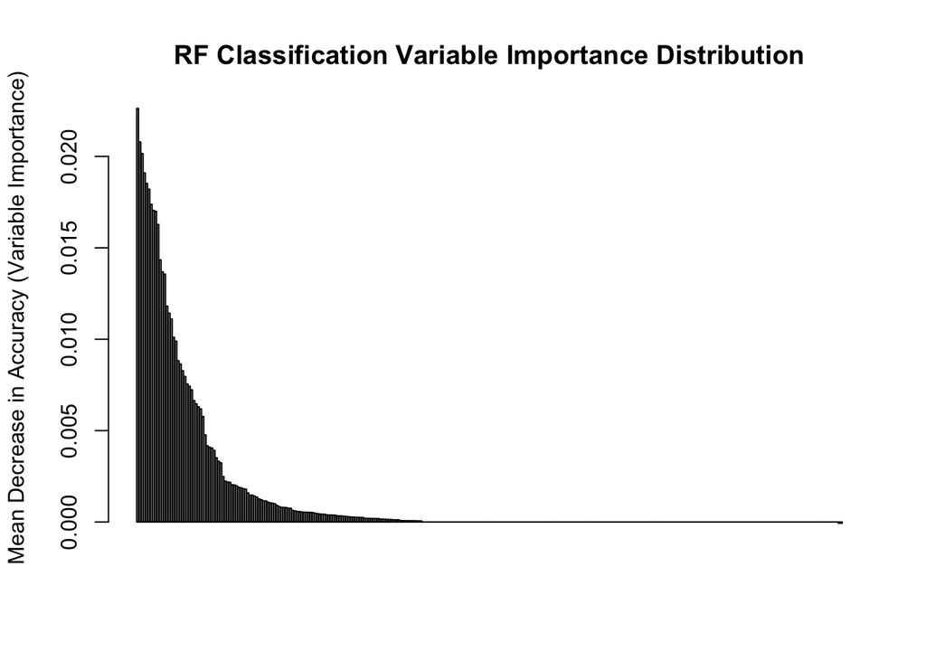

```r
#### Indentifyng important predictor variables

RF_sex_classify_imp <- as.data.frame(RF_sex_classify$importance)
RF_sex_classify_imp$features <- rownames(RF_sex_classify_imp)
RF_sex_classify_imp_sorted <- arrange(RF_sex_classify_imp  , desc(MeanDecreaseAccuracy))

## plot of the distribution of improtance for accuracy
barplot(RF_sex_classify_imp_sorted$MeanDecreaseAccuracy,
        ylab="Mean Decrease in Accuracy (Variable Importance)",
        main="RF Classification Variable Importance Distribution")
```

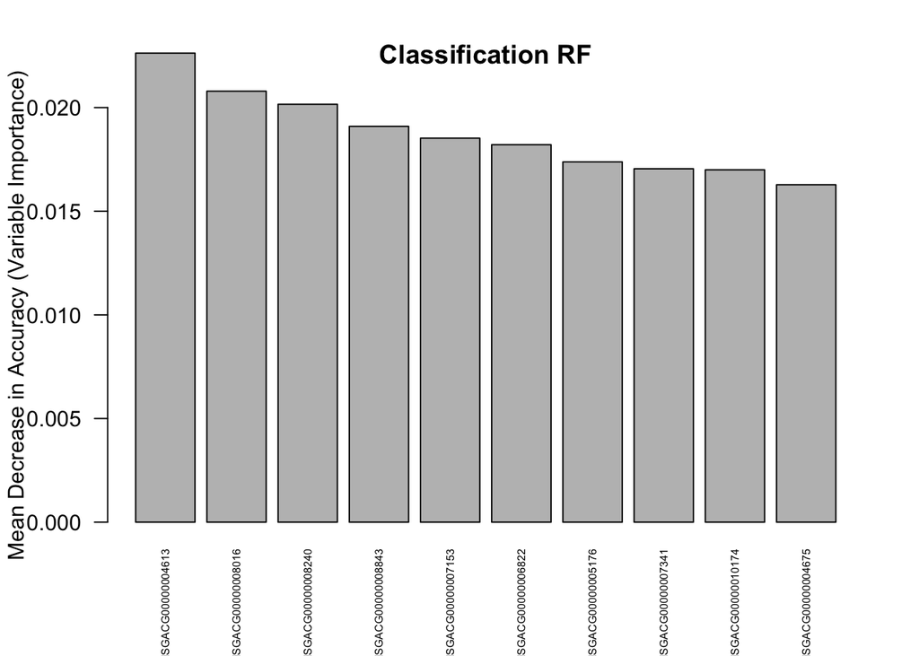

```r
## now let's just look at the 10 most important predictor variables
barplot(RF_sex_classify_imp_sorted[1:10,"MeanDecreaseAccuracy"],
        names.arg=RF_sex_classify_imp_sorted[1:10,"features"] ,
        ylab="Mean Decrease in Accuracy (Variable Importance)",
        las=2, ylim=c(0,0.02), main="Classification RF", cex.names = 0.5)
```

### Random Forrest - Random Genes

```r
## subset only the data columns and log-transform
RF_expr <- log2(stickle_rand[,3:86]+.01)

# Mean-center and range data (mean 0, sd 1). Must transpose for row wise scaling
RF_expr.n <- data.frame(scale(t(RF_expr)))

## add the classifier variable (rand, in this case)
RF_expr.n$rand <- stickle_meta[,2]
#head(RF_expr.n)

## Run RF to classify males and females
## ntree = number of dec. trees (501 is pretty low, but will be fast)
## mtry = number of variables randomly sampled at each tree node. Default sqrt(num predictors)
  #RF_rand_classify <- randomForest(x=RF_expr.n[,1:314],
  #                                y=RF_expr.n[,315],
  #                                ntree=501, importance=TRUE,
  #                                proximities=TRUE)
  #saveRDS(RF_rand_classify, 'RF_rand_classify.rds')
  #

RF_rand_classify <- readRDS('data/RF_rand_classify.rds')
RF_rand_classify
```

```
##
## Call:
##  randomForest(x = RF_expr.n[, 1:314], y = RF_expr.n[, 315], ntree = 501,      importance = TRUE, proximities = TRUE)
##                Type of random forest: classification
##                      Number of trees: 501
## No. of variables tried at each split: 17
##
##         OOB estimate of  error rate: 2.38%
## Confusion matrix:
##        female male class.error
## female     39    1  0.02500000
## male        1   43  0.02272727
```

```r
## Fit implies perfect classification, but can also evaluate with a permutation test
## This will take several minutes, so I won't re-run during class.
  #RF_rand_classify_sig <- rf.significance(x=RF_rand_classify,  xdata=RF_expr.n[,1:314],
  #                                       nperm=1000, ntree=501 )
  #saveRDS(RF_rand_classify_sig, 'RF_rand_classify_sig.rds')


RF_rand_classify_sig <- readRDS('data/RF_rand_classify_sig.rds')
RF_rand_classify_sig
```

```
## Number of permutations:  1000
## p-value:  0
## Model signifiant at p = 0
##   Model OOB error:  0.03571429
##   Random OOB error:  0.5119048
##   min random global error: 0.3333333
##   max random global error:  0.75
##   min random within class error: 0.5263158
##   max random within class error:  0.5263158
```

```r
## Model also classifies significantly better than expected by chance.



#### Cross-validation using the "leave-one-out" strategy

## specify this cross-validation strategy:
fit_control <- trainControl( method = "LOOCV" )

## do the training, with the same parameters as above
  #RF_rand_classify_loocv <- train(RF_expr.n[,1:314],
  #                               y=RF_expr.n[,315],
  #                               method="rf", ntree=501, tuneGrid=data.frame(mtry=17),
  #                               trControl=fit_control)
  #saveRDS(RF_rand_classify_loocv, 'RF_rand_classify_loocv.rds')


RF_rand_classify_loocv <- readRDS('data/RF_rand_classify_loocv.rds')
RF_rand_classify_loocv
```

```
## Random Forest
##
##  84 samples
## 314 predictors
##   2 classes: 'female', 'male'
##
## No pre-processing
## Resampling: Leave-One-Out Cross-Validation
## Summary of sample sizes: 83, 83, 83, 83, 83, 83, ...
## Resampling results:
##
##   Accuracy   Kappa
##   0.9642857  0.9283276
##
## Tuning parameter 'mtry' was held constant at a value of 17
```

```r
## look at the performance
RF_rand_classify_loocv$results
```

```
##   mtry  Accuracy     Kappa
## 1   17 0.9642857 0.9283276
```

```r
# This is an extremely well-fiting RF model

## look at predicted (when left out) compared to observed
head(RF_rand_classify_loocv$pred)
```

```
##     pred    obs rowIndex mtry
## 1   male   male        1   17
## 2 female female        2   17
## 3 female female        3   17
## 4   male   male        4   17
## 5 female female        5   17
## 6   male   male        6   17
```

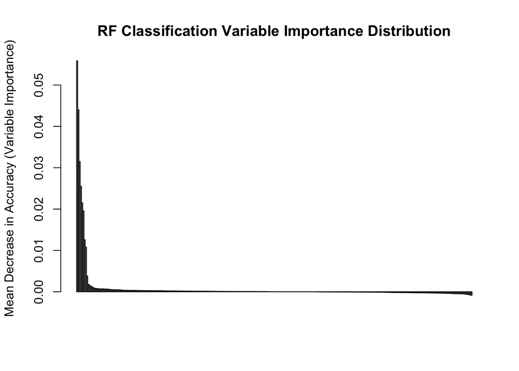

```r
#### Indentifyng important predictor variables
RF_rand_classify_imp <- as.data.frame(RF_rand_classify$importance)
RF_rand_classify_imp$features <- rownames(RF_rand_classify_imp)
RF_rand_classify_imp_sorted <- arrange(RF_rand_classify_imp  , desc(MeanDecreaseAccuracy))

## plot of the distribution of improtance for accuracy
barplot(RF_rand_classify_imp_sorted$MeanDecreaseAccuracy,
        ylab="Mean Decrease in Accuracy (Variable Importance)",
        main="RF Classification Variable Importance Distribution")
```

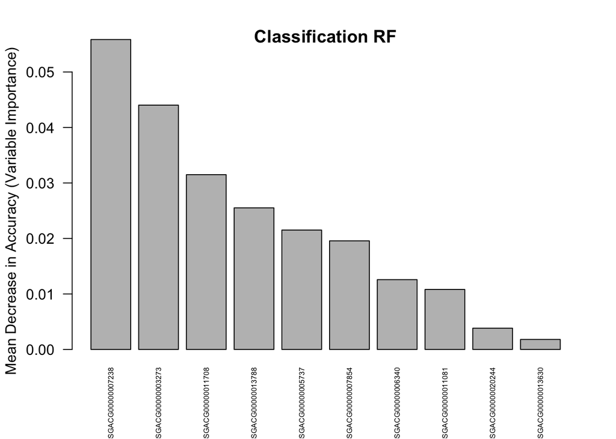

```r
## now let's just look at the 10 most important predictor variables
barplot(RF_rand_classify_imp_sorted[1:10,"MeanDecreaseAccuracy"],
        names.arg=RF_rand_classify_imp_sorted[1:10,"features"] ,
        ylab="Mean Decrease in Accuracy (Variable Importance)",
        las=2, ylim=c(0,0.05), main="Classification RF", cex.names = 0.5)
```

Taking a look at the top five classifying genes:

```r
genes <- RF_rand_classify_imp_sorted[1:5,]$features

stickleback_genes <- read.delim('data/mart_export.txt', sep='\t', header = TRUE)

stickleback_genes[stickleback_genes$Gene.stable.ID %in% genes,]
```

```
##           Gene.stable.ID
## 3148  ENSGACG00000003273
## 5506  ENSGACG00000005737
## 6951  ENSGACG00000007238
## 11282 ENSGACG00000011708
## 13335 ENSGACG00000013788
##                                                                                                         Gene.description
## 3148                                                                 anoctamin 10b [Source:ZFIN;Acc:ZDB-GENE-061013-169]
## 5506                                                        serum amyloid A-like 1 [Source:ZFIN;Acc:ZDB-GENE-040426-725]
## 6951                                   peptidylprolyl isomerase B (cyclophilin B) [Source:ZFIN;Acc:ZDB-GENE-040426-1955]
## 11282 pleckstrin homology domain containing, family G (with RhoGef domain) member 7 [Source:ZFIN;Acc:ZDB-GENE-070410-15]
## 13335                                                                  zgc:173742 [Source:ZFIN;Acc:ZDB-GENE-030131-6489]
##        Gene.name Chromosome.scaffold.name
## 3148      ano10b                 groupXIX
## 5506       saal1                 groupXIX
## 6951        ppib                 groupXIX
## 11282    plekhg7                 groupXIX
## 13335 zgc:173742                 groupXIX
```

Ahh look, they are all from chromosome 19, where the sex specific genes are!

## RF classification of IDB diagnosis using HMP metagenomic data

First we read in the provided ibd dataset, and look at the metadata.

```r
ibd <- read.delim('data/pathabundances_IBD.tsv', sep='\t', header=TRUE)
dim(ibd)
```

```
## [1] 466  57
```

```r
ibd_meta <- read.delim('data/metadata_IBD_all.tsv', sep='\t', header=TRUE)
head(ibd_meta)
```

```
##   Project External_ID Participant_ID site_sub_coll    data_type week_num
## 1 G116705    CSM79HHO          C3021       C3021C2 metagenomics        1
## 2 G110648    CSM79HKX          C3028       C3028C2 metagenomics        1
## 3 G110574    CSM79HNE          C3029       C3029C2 metagenomics        1
## 4 G110615    CSM7KOP6          C3032       C3032C2 metagenomics        2
## 5 G110633    CSM7KOTO          C3035       C3035C3 metagenomics        4
## 6 G109894    MSM5LLDI          M2008       M2008C1 metagenomics        0
##   interval_days visit_num total_reads trimmed_reads filtered_reads
## 1             7         2    11855793            NA             NA
## 2            13         2    29028121            NA             NA
## 3            13         2    16431599            NA             NA
## 4            14         2    14407582            NA             NA
## 5            14         3    14086984            NA             NA
## 6             0         1    21442133            NA             NA
##   frac_human_reads ProjectSpecificID    site_name Age_diagnosis
```

[output cut: 20 more lines]

The dataset is a shotgun metagenomic dataset of IBD patients containing 33 Crohn’s Disease and 23 Ulcerative Colitis patients. There are 466 rows corresponding to different pathways, and 57 total columns, one for each patient. The metadata have lots of information about the participants, weeks, days, coverage information, diagnosis, if the patient was on antibiotics or not, their race, sex, and sample types. The colnames of the ibd data correspond to the ‘External_ID’ column of the metadata, so we can look at that.

Let’s see if nMDS groups the patients by UC, or CD diagnosis.

```r
# subset the data and transpose
nmds_ibd <- t(ibd[,2:ncol(ibd)])

rownames(nmds_ibd) <- ibd_meta$diagnosis

## Generate dissimilarity matrix
vare.dis <- vegdist(nmds_ibd)

## Generate nmds "latent variables" and evaluate fit
vare.mds0 <- isoMDS(vare.dis, k=2)
```

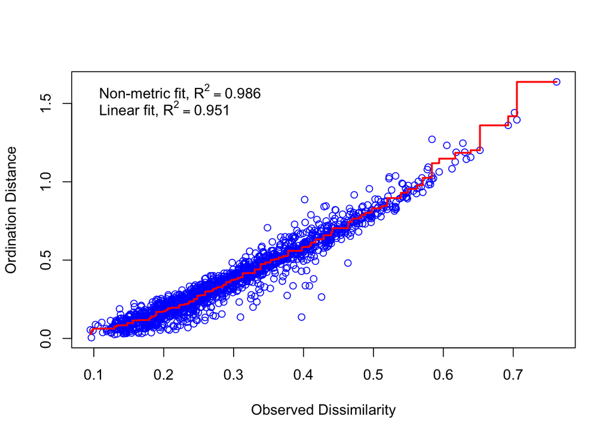

```r
stressplot(vare.mds0, vare.dis)
```

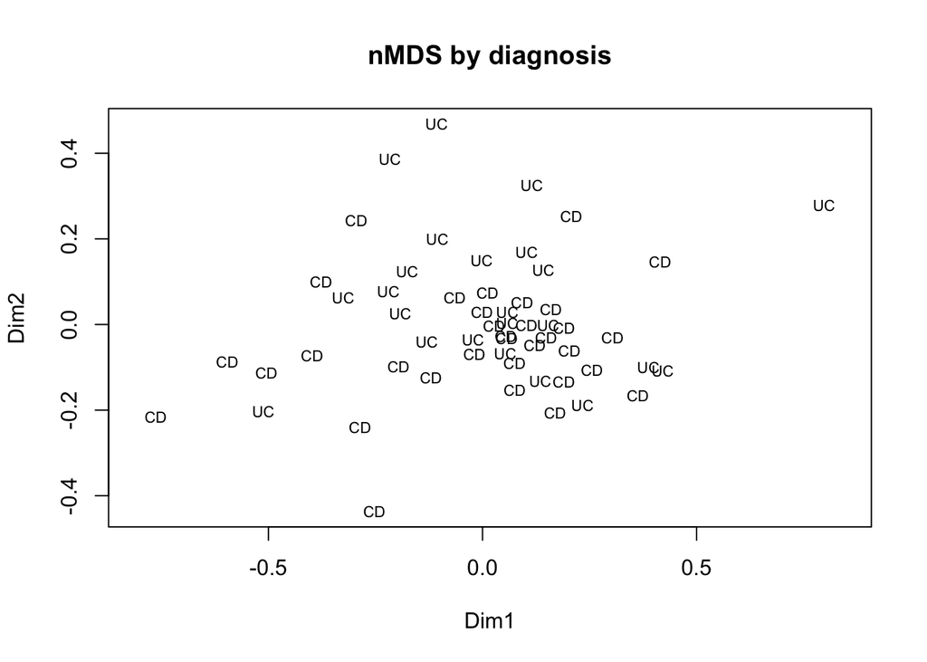

```r
## plot nmds 2 vs nmds 1
ordiplot(vare.mds0, type = "t", main='nMDS by diagnosis')
```

nMDS doesnot separate the patients well by diagnosis. Maybe it separates them by another categorical.

#### By sex

```r
ord_by_colname <- function(colname) {

  # subset the data and transpose
  nmds_ibd <- t(ibd[,2:ncol(ibd)])

  rownames(nmds_ibd) <- ibd_meta[[colname]]

  ## Generate dissimilarity matrix
  vare.dis <- vegdist(nmds_ibd)

  ## Generate nmds "latent variables" and evaluate fit
  vare.mds0 <- isoMDS(vare.dis, k=2)
  #stressplot(vare.mds0, vare.dis)


  ## plot nmds 2 vs nmds 1
  ordiplot(vare.mds0, type = "t", main=paste('nMDS by', colname))
}


colnames(ibd_meta)
```

```
##  [1] "Project"           "External_ID"       "Participant_ID"
##  [4] "site_sub_coll"     "data_type"         "week_num"
##  [7] "interval_days"     "visit_num"         "total_reads"
## [10] "trimmed_reads"     "filtered_reads"    "frac_human_reads"
## [13] "ProjectSpecificID" "site_name"         "Age_diagnosis"
## [16] "consent_age"       "diagnosis"         "Antibiotics"
## [19] "HispanicOrLatino"  "race"              "sccai"
## [22] "sex"               "stool_collected"   "fecalcal"
```

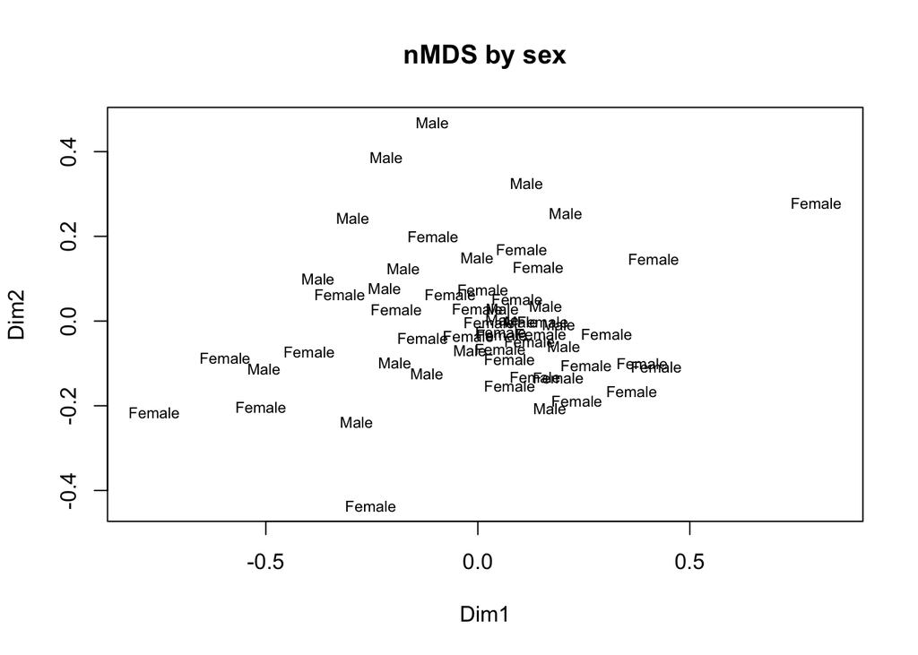

```r
# by sex
ord_by_colname('sex')
```

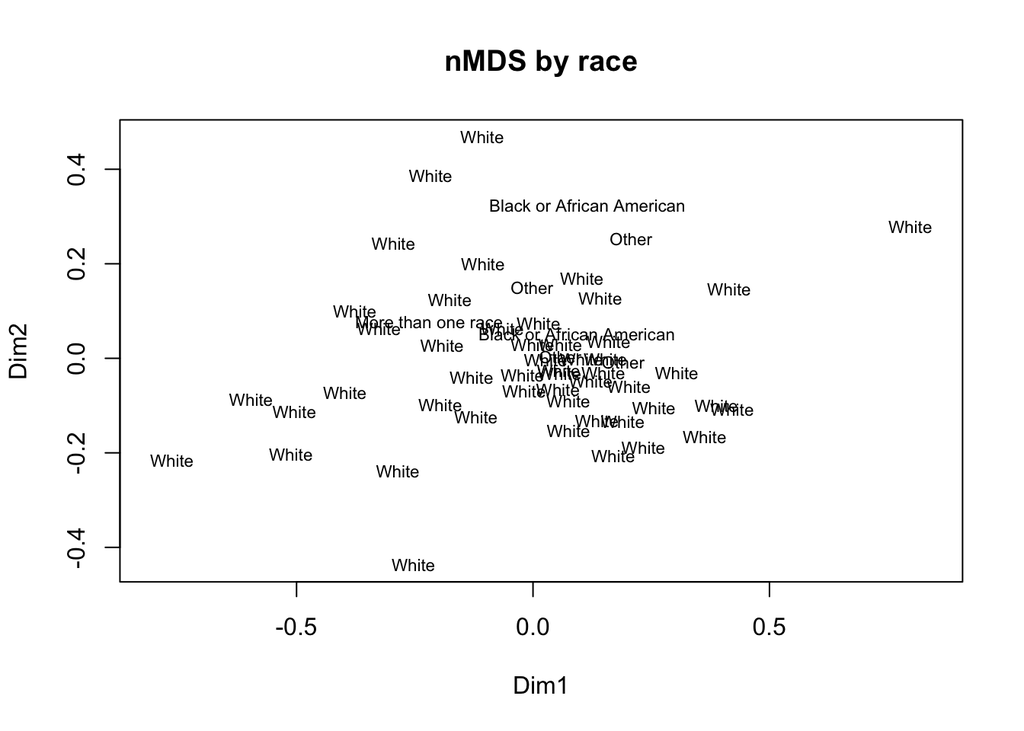

```r
# by race
ord_by_colname('race')
```

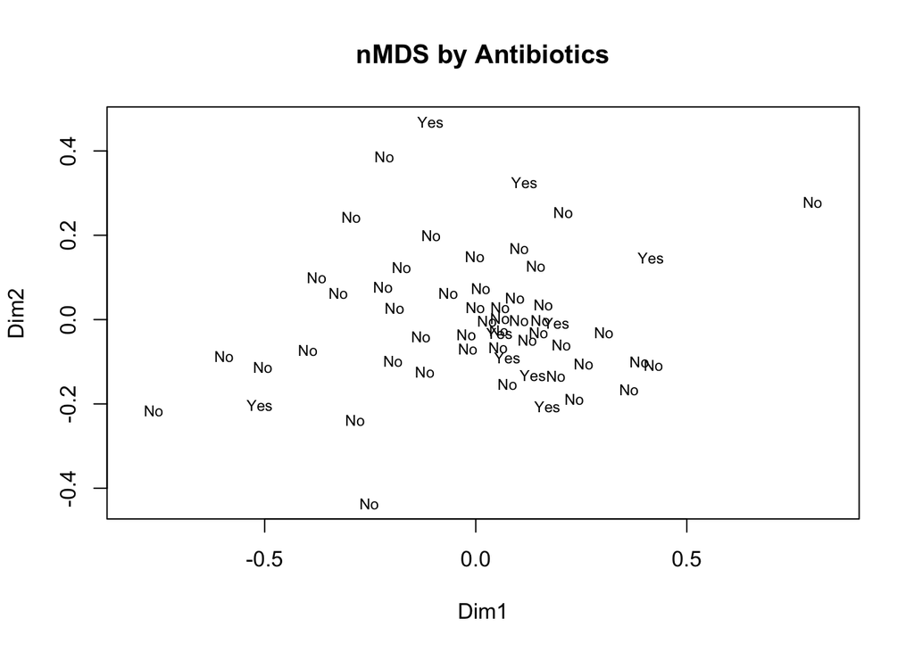

```r
# by antibiotics
ord_by_colname('Antibiotics')
```

nMDS is not separating any of these categories. Let’s see how random forrest does!

## Random Forrest

```r
# scale the data rowwise
RF_ibd <- scale(t(ibd[,2:ncol(ibd)]))

# replace Nans
RF_ibd[is.nan(RF_ibd)] <- 0
RF_ibd <- data.frame(RF_ibd)

# add the classifier variable (diagnosis)
RF_ibd$diagnosis <- ibd_meta$diagnosis

# random forrest
RF_ibd_classify <- randomForest(x=RF_ibd[,1:(ncol(RF_ibd)-1)],
                                y=RF_ibd[,ncol(RF_ibd)],
                                ntree=501, importance=TRUE,
                                proximities=TRUE)


RF_ibd_classify
```

```
##
## Call:
##  randomForest(x = RF_ibd[, 1:(ncol(RF_ibd) - 1)], y = RF_ibd[,      ncol(RF_ibd)], ntree = 501, importance = TRUE, proximities = TRUE)
##                Type of random forest: classification
##                      Number of trees: 501
## No. of variables tried at each split: 21
##
##         OOB estimate of  error rate: 50%
## Confusion matrix:
##    CD UC class.error
## CD 25  8   0.2424242
## UC 20  3   0.8695652
```

The RF classification has a 50% error rate, this is not the best. Maybe the permutation test will do better:

```r
#RF_ibd_classify_sig <- rf.significance(x=RF_ibd_classify,  xdata=RF_ibd[,1:(ncol(RF_ibd)-1)],
#                                       nperm=1000, ntree=501 )
#
#saveRDS(RF_ibd_classify_sig, 'data/RF_ibd_classify_sig.rds')

RF_ibd_classify_sig <- readRDS('data/RF_ibd_classify_sig.rds')

RF_ibd_classify_sig
```

```
## Number of permutations:  1000
## p-value:  0.573
## Model not signifiant at p = 0.573
##   Model OOB error:  0.5
##   Random OOB error:  0.4821429
##   min random global error: 0.2142857
##   max random global error:  0.6964286
##   min random within class error: 0.5652174
##   max random within class error:  0.5652174
```

```r
#### Cross-validation using the "leave-one-out" strategy

## specify this cross-validation strategy:
fit_control <- trainControl( method = "LOOCV" )

## do the training, with the same parameters as above
RF_ibd_classify_loocv <- train(RF_ibd[,1:(ncol(RF_ibd)-1)],
                               y=RF_ibd[,ncol(RF_ibd)],
                               method="rf", ntree=501, tuneGrid=data.frame(mtry=17),
                               trControl=fit_control)

RF_ibd_classify_loocv
```

```
## Random Forest
##
##  56 samples
## 466 predictors
##   2 classes: 'CD', 'UC'
##
## No pre-processing
## Resampling: Leave-One-Out Cross-Validation
## Summary of sample sizes: 55, 55, 55, 55, 55, 55, ...
## Resampling results:
##
##   Accuracy  Kappa
##   0.5       -0.1216023
##
## Tuning parameter 'mtry' was held constant at a value of 17
```

```r
## look at the performance
RF_ibd_classify_loocv$results
```

```
##   mtry Accuracy      Kappa
## 1   17      0.5 -0.1216023
```

```r
# This is an extremely well-fiting RF model

## look at predicted (when left out) compared to observed
RF_ibd_classify_loocv$pred
```

```
##    pred obs rowIndex mtry
## 1    UC  CD        1   17
## 2    CD  CD        2   17
## 3    CD  UC        3   17
## 4    CD  UC        4   17
## 5    UC  CD        5   17
## 6    CD  CD        6   17
## 7    CD  UC        7   17
## 8    CD  UC        8   17
## 9    UC  UC        9   17
## 10   UC  CD       10   17
## 11   UC  CD       11   17
## 12   CD  UC       12   17
## 13   CD  UC       13   17
## 14   CD  CD       14   17
```

[output cut: 42 more lines]

Classification accuracy with leave-one-out cross validation is about 0.5

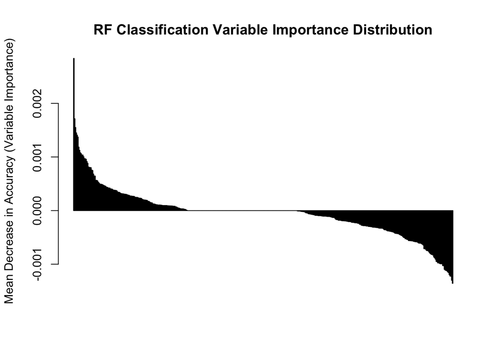

```r
#### Indentifyng important predictor variables

RF_ibd_classify_imp <- as.data.frame(RF_ibd_classify$importance)
RF_ibd_classify_imp$features <- rownames(RF_ibd_classify_imp)
RF_ibd_classify_imp_sorted <- arrange(RF_ibd_classify_imp  , desc(MeanDecreaseAccuracy))

## plot of the distribution of improtance for accuracy
barplot(RF_ibd_classify_imp_sorted$MeanDecreaseAccuracy,
        ylab="Mean Decrease in Accuracy (Variable Importance)",
        main="RF Classification Variable Importance Distribution")
```

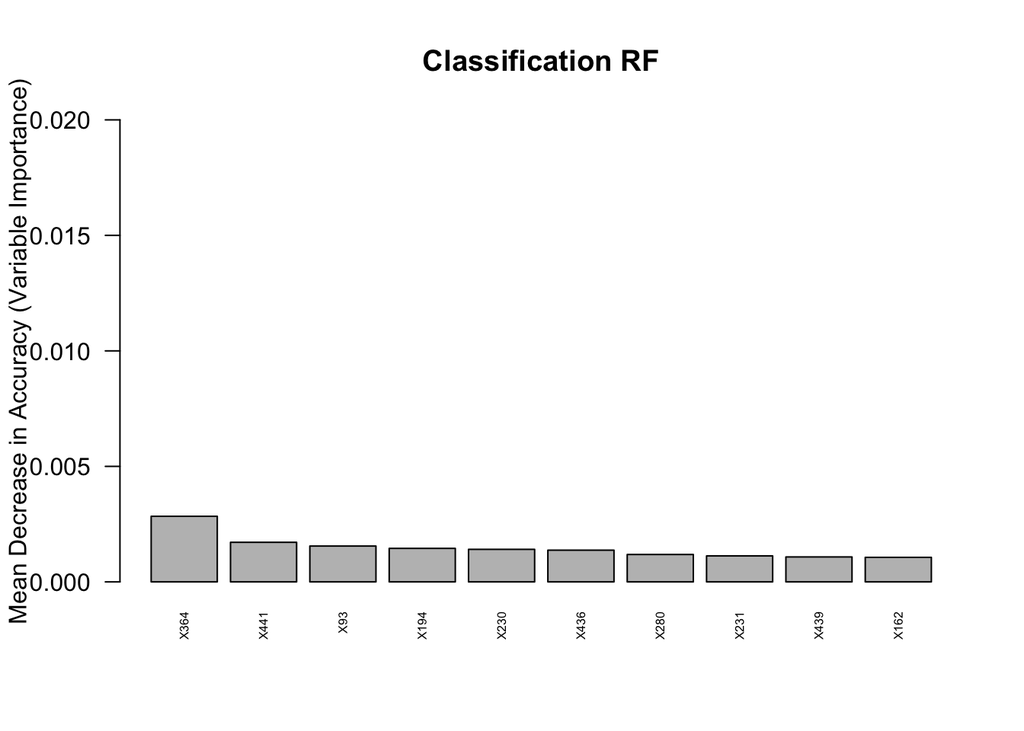

```r
## now let's just look at the 10 most important predictor variables
barplot(RF_ibd_classify_imp_sorted[1:10,"MeanDecreaseAccuracy"],
        names.arg=RF_ibd_classify_imp_sorted[1:10,"features"] ,
        ylab="Mean Decrease in Accuracy (Variable Importance)",
        las=2, ylim=c(0,0.02), main="Classification RF", cex.names = 0.5)
```

The accuracy of the classifier and the above plots shows that the random forrest classifier doesn’t do much better than random chance at diagnosing CD vs. UC with these metagenomic data.